# Predict Bike Sharing Demand with AutoGluon Template

## Project: Predict Bike Sharing Demand with AutoGluon

This notebook is a template with each step that you need to complete for the project.

Please fill in your code where there are explicit `?` markers in the notebook. You are welcome to add more cells and code as you see fit.

Once you have completed all the code implementations, please export your notebook as a HTML file so the reviews can view your code. Make sure you have all outputs correctly outputted.

`File-> Export Notebook As... -> Export Notebook as HTML`

There is a writeup to complete as well after all code implememtation is done. Please answer all questions and attach the necessary tables and charts. You can complete the writeup in either markdown or PDF.

Completing the code template and writeup template will cover all of the rubric points for this project.

The rubric contains "Stand Out Suggestions" for enhancing the project beyond the minimum requirements. The stand out suggestions are optional. If you decide to pursue the "stand out suggestions", you can include the code in this notebook and also discuss the results in the writeup file.

```python
pip install bokeh==2.0.1
```

```
     ---------------------------------------- 8.6/8.6 MB 375.7 kB/s eta 0:00:00
  Preparing metadata (setup.py): started
  Preparing metadata (setup.py): finished with status 'done'
```

```python
import kaggle
```

```python
!kaggle competitions download -c bike-sharing-demand
```

```
Downloading bike-sharing-demand.zip to D:\Projects\Bike_Sharing_Demand-main\project
```

[output not shown]

```python
import pandas as pd
from autogluon.tabular import TabularPredictor
```

```python
import autogluon.core as ag
```

```python
import numpy as np
```

```python
# Create the train dataset in pandas by reading the csv
# Set the parsing of the datetime column so you can use some of the `dt` features in pandas later
train = pd.read_csv('data/train.csv')
train.head()
```

|  | datetime | season | holiday | workingday | weather | temp | atemp | humidity | windspeed | casual | registered | count |
| --- | --- | --- | --- | --- | --- | --- | --- | --- | --- | --- | --- | --- |
| 0 | 2011-01-01 00:00:00 | 1 | 0 | 0 | 1 | 9.84 | 14.395 | 81 | 0.0 | 3 | 13 | 16 |
| 1 | 2011-01-01 01:00:00 | 1 | 0 | 0 | 1 | 9.02 | 13.635 | 80 | 0.0 | 8 | 32 | 40 |
| 2 | 2011-01-01 02:00:00 | 1 | 0 | 0 | 1 | 9.02 | 13.635 | 80 | 0.0 | 5 | 27 | 32 |
| 3 | 2011-01-01 03:00:00 | 1 | 0 | 0 | 1 | 9.84 | 14.395 | 75 | 0.0 | 3 | 10 | 13 |
| 4 | 2011-01-01 04:00:00 | 1 | 0 | 0 | 1 | 9.84 | 14.395 | 75 | 0.0 | 0 | 1 | 1 |

```python
# Simple output of the train dataset to view some of the min/max/varition of the dataset features.
train.describe()
```

|  | season | holiday | workingday | weather | temp | atemp | humidity | windspeed | casual | registered | count |
| --- | --- | --- | --- | --- | --- | --- | --- | --- | --- | --- | --- |
| count | 10886.000000 | 10886.000000 | 10886.000000 | 10886.000000 | 10886.00000 | 10886.000000 | 10886.000000 | 10886.000000 | 10886.000000 | 10886.000000 | 10886.000000 |
| mean | 2.506614 | 0.028569 | 0.680875 | 1.418427 | 20.23086 | 23.655084 | 61.886460 | 12.799395 | 36.021955 | 155.552177 | 191.574132 |
| std | 1.116174 | 0.166599 | 0.466159 | 0.633839 | 7.79159 | 8.474601 | 19.245033 | 8.164537 | 49.960477 | 151.039033 | 181.144454 |
| min | 1.000000 | 0.000000 | 0.000000 | 1.000000 | 0.82000 | 0.760000 | 0.000000 | 0.000000 | 0.000000 | 0.000000 | 1.000000 |
| 25% | 2.000000 | 0.000000 | 0.000000 | 1.000000 | 13.94000 | 16.665000 | 47.000000 | 7.001500 | 4.000000 | 36.000000 | 42.000000 |
| 50% | 3.000000 | 0.000000 | 1.000000 | 1.000000 | 20.50000 | 24.240000 | 62.000000 | 12.998000 | 17.000000 | 118.000000 | 145.000000 |
| 75% | 4.000000 | 0.000000 | 1.000000 | 2.000000 | 26.24000 | 31.060000 | 77.000000 | 16.997900 | 49.000000 | 222.000000 | 284.000000 |
| max | 4.000000 | 1.000000 | 1.000000 | 4.000000 | 41.00000 | 45.455000 | 100.000000 | 56.996900 | 367.000000 | 886.000000 | 977.000000 |

```python
# Create the test pandas dataframe in pandas by reading the csv, remember to parse the datetime!
test = pd.read_csv('data/test.csv')
test.head()
```

|  | datetime | season | holiday | workingday | weather | temp | atemp | humidity | windspeed |
| --- | --- | --- | --- | --- | --- | --- | --- | --- | --- |
| 0 | 2011-01-20 00:00:00 | 1 | 0 | 1 | 1 | 10.66 | 11.365 | 56 | 26.0027 |
| 1 | 2011-01-20 01:00:00 | 1 | 0 | 1 | 1 | 10.66 | 13.635 | 56 | 0.0000 |
| 2 | 2011-01-20 02:00:00 | 1 | 0 | 1 | 1 | 10.66 | 13.635 | 56 | 0.0000 |
| 3 | 2011-01-20 03:00:00 | 1 | 0 | 1 | 1 | 10.66 | 12.880 | 56 | 11.0014 |
| 4 | 2011-01-20 04:00:00 | 1 | 0 | 1 | 1 | 10.66 | 12.880 | 56 | 11.0014 |

```python
# Same thing as train and test dataset
submission = pd.read_csv('data/sampleSubmission.csv')
submission.head()
```

|  | datetime | count |
| --- | --- | --- |
| 0 | 2011-01-20 00:00:00 | 0 |
| 1 | 2011-01-20 01:00:00 | 0 |
| 2 | 2011-01-20 02:00:00 | 0 |
| 3 | 2011-01-20 03:00:00 | 0 |
| 4 | 2011-01-20 04:00:00 | 0 |

## Step 3: Train a model using AutoGluon’s Tabular Prediction

Requirements:

- We are prediting `count`, so it is the label we are setting.
- Ignore `casual` and `registered` columns as they are also not present in the test dataset.
- Use the `root_mean_squared_error` as the metric to use for evaluation.
- Set a time limit of 10 minutes (600 seconds).
- Use the preset `best_quality` to focus on creating the best model.

```python
train.drop(['casual','registered'],axis=1,inplace=True)
```

```python
train.head()
```

|  | datetime | season | holiday | workingday | weather | temp | atemp | humidity | windspeed | count |
| --- | --- | --- | --- | --- | --- | --- | --- | --- | --- | --- |
| 0 | 2011-01-01 00:00:00 | 1 | 0 | 0 | 1 | 9.84 | 14.395 | 81 | 0.0 | 16 |
| 1 | 2011-01-01 01:00:00 | 1 | 0 | 0 | 1 | 9.02 | 13.635 | 80 | 0.0 | 40 |
| 2 | 2011-01-01 02:00:00 | 1 | 0 | 0 | 1 | 9.02 | 13.635 | 80 | 0.0 | 32 |
| 3 | 2011-01-01 03:00:00 | 1 | 0 | 0 | 1 | 9.84 | 14.395 | 75 | 0.0 | 13 |
| 4 | 2011-01-01 04:00:00 | 1 | 0 | 0 | 1 | 9.84 | 14.395 | 75 | 0.0 | 1 |

```python
predictor = TabularPredictor(label='count', eval_metric='root_mean_squared_error').fit(train, time_limit= 10*60, presets="best_quality")
```

[output not shown]

[output cut: 17 more lines]

[output not shown]

[output not shown]

[output cut: 177 more lines]

[output not shown]

### Review AutoGluon's training run with ranking of models that did the best.

```python
predictor.fit_summary()
```

```
*** Summary of fit() ***
Estimated performance of each model:
                     model   score_val  pred_time_val    fit_time  pred_time_val_marginal  fit_time_marginal  stack_level  can_infer  fit_order
0      WeightedEnsemble_L3  -50.257112      12.929147  366.492439                0.000000           0.235512            3       True         22
1   NeuralNetFastAI_BAG_L2  -51.272288      11.861319  267.756280                0.296489          22.385300            2       True         18
2   RandomForestMSE_BAG_L2  -53.430250      11.982179  251.280609                0.417350           5.909628            2       True         15
3     ExtraTreesMSE_BAG_L2  -54.023319      11.976223  247.310938                0.411393           1.939958            2       True         17
4     LightGBMLarge_BAG_L2  -54.852476      11.781393  252.154891                0.216563           6.783910            2       True         21
5          LightGBM_BAG_L2  -54.910914      11.737442  248.942029                0.172612           3.571048            2       True         14
6    NeuralNetTorch_BAG_L2  -54.943643      11.803915  336.022040                0.239085          90.651060            2       True         20
7           XGBoost_BAG_L2  -54.987724      11.654600  252.555773                0.089771           7.184793            2       True         19
8          CatBoost_BAG_L2  -55.708411      11.587229  271.819902                0.022400          26.448922            2       True         16
9        LightGBMXT_BAG_L2  -60.025657      14.294386  256.022885                2.729556          10.651904            2       True         13
10   KNeighborsDist_BAG_L1  -84.146423       0.017005    0.052011                0.017005           0.052011            1       True          2
11     WeightedEnsemble_L2  -84.146423       0.018025    0.367152                0.001020           0.315141            2       True         12
12   KNeighborsUnif_BAG_L1 -101.588176       0.016004    0.052012                0.016004           0.052012            1       True          1
13  RandomForestMSE_BAG_L1 -116.543822       0.361586    1.496843                0.361586           1.496843            1       True          5
14    ExtraTreesMSE_BAG_L1 -124.594043       0.346280    1.054101                0.346280           1.054101            1       True          7
15    LightGBMLarge_BAG_L1 -130.132290       0.539920    4.787623                0.539920           4.787623            1       True         11
16         CatBoost_BAG_L1 -130.461205       0.025006  117.457501                0.025006         117.457501            1       True          6
17         LightGBM_BAG_L1 -131.054162       0.741669    3.389189                0.741669           3.389189            1       True          4
18       LightGBMXT_BAG_L1 -131.460909       8.951774    8.336376                8.951774           8.336376            1       True          3
19          XGBoost_BAG_L1 -131.624665       0.167831    5.197966                0.167831           5.197966            1       True          9
20  NeuralNetFastAI_BAG_L1 -135.845258       0.205381   19.628907                0.205381          19.628907            1       True          8
21   NeuralNetTorch_BAG_L1 -138.119903       0.192373   83.918450                0.192373          83.918450            1       True         10
Number of models trained: 22
Types of models trained:
{'StackerEnsembleModel_KNN', 'StackerEnsembleModel_CatBoost', 'StackerEnsembleModel_TabularNeuralNetTorch', 'WeightedEnsembleModel', 'StackerEnsembleModel_NNFastAiTabular', 'StackerEnsembleModel_XGBoost', 'StackerEnsembleModel_XT', 'StackerEnsembleModel_RF', 'StackerEnsembleModel_LGB'}
Bagging used: True  (with 8 folds)
Multi-layer stack-ensembling used: True  (with 3 levels)
Feature Metadata (Processed):
(raw dtype, special dtypes):
('float', [])                : 3 | ['temp', 'atemp', 'windspeed']
('int', [])                  : 3 | ['season', 'weather', 'humidity']
('int', ['bool'])            : 2 | ['holiday', 'workingday']
('int', ['datetime_as_int']) : 5 | ['datetime', 'datetime.year', 'datetime.month', 'datetime.day', 'datetime.dayofweek']
*** End of fit() summary ***
```

[output not shown]

[output cut: 223 more lines]

[output not shown]

### Create predictions from test dataset

```python
predictions =predictor.predict(test)

predictions.head()
```

```
0    24.216393
1    40.614311
2    46.007603
3    47.458683
4    49.840912
Name: count, dtype: float32
```

#### NOTE: Kaggle will reject the submission if we don't set everything to be > 0.

```python
# Describe the `predictions` series to see if there are any negative values
predictions.describe()
```

```
count    6493.000000
mean       99.750961
std        88.438271
min        -0.903439
25%        21.550217
50%        66.916191
75%       168.007385
max       349.708832
Name: count, dtype: float64
```

```python
# How many negative values do we have?
b=np.array(predictions)
print(sum(b<0))
```

```
2
```

```python
# Set them to zero
predictions=np.where(predictions < 0.0, 0, predictions)
```

```python
b=np.array(predictions)
print(sum(b<0))
```

```
0
```

```python
predictions= pd.DataFrame(predictions)
```

```python
predictions.info()
```

```
<class 'pandas.core.frame.DataFrame'>
RangeIndex: 6493 entries, 0 to 6492
Data columns (total 1 columns):
 #   Column  Non-Null Count  Dtype
---  ------  --------------  -----
 0   0       6493 non-null   float32
dtypes: float32(1)
memory usage: 25.5 KB
```

```python
predictions.describe()
```

|  | 0 |
| --- | --- |
| count | 6493.000000 |
| mean | 99.751228 |
| std | 88.437981 |
| min | 0.000000 |
| 25% | 21.550217 |
| 50% | 66.916191 |
| 75% | 168.007385 |
| max | 349.708832 |

### Set predictions to submission dataframe, save, and submit

```python
submission["count"] = predictions
submission.to_csv("submission.csv", index=False)
```

```python
!kaggle competitions submit -c bike-sharing-demand -f submission.csv -m "first raw submission"
```

```
Successfully submitted to Bike Sharing Demand
```

```
  4%|4         | 8.00k/195k [00:00<00:08, 21.6kB/s]
 41%|####1     | 80.0k/195k [00:00<00:00, 213kB/s]
 66%|######5   | 128k/195k [00:00<00:00, 233kB/s]
 99%|#########8| 192k/195k [00:00<00:00, 315kB/s]
```

#### View submission via the command line or in the web browser under the competition's page - `My Submissions`

```python
!kaggle competitions submissions -c bike-sharing-demand | tail -n +1 | head -n 6
```

```
'tail' is not recognized as an internal or external command,
operable program or batch file.
```

## Step 4: Exploratory Data Analysis and Creating an additional feature

- Any additional feature will do, but a great suggestion would be to separate out the datetime into hour, day, or month parts.

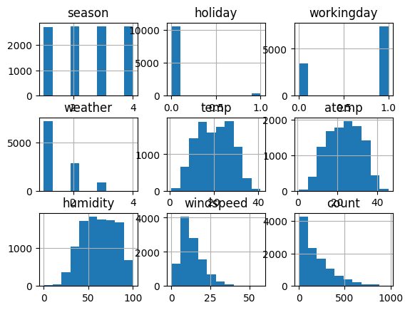

```python
# Create a histogram of all features to show the distribution of each one relative to the data. This is part of the exploritory data analysis
train.hist();
```

```python
train['datetime']=pd.to_datetime(train['datetime'])
```

```python
test['datetime']=pd.to_datetime(test['datetime'])
```

```python
train.datetime.dtype
```

```
dtype('<M8[ns]')
```

```python
train.info()
```

```
<class 'pandas.core.frame.DataFrame'>
RangeIndex: 10886 entries, 0 to 10885
Data columns (total 10 columns):
 #   Column      Non-Null Count  Dtype
---  ------      --------------  -----
 0   datetime    10886 non-null  datetime64[ns]
 1   season      10886 non-null  int64
 2   holiday     10886 non-null  int64
 3   workingday  10886 non-null  int64
 4   weather     10886 non-null  int64
 5   temp        10886 non-null  float64
 6   atemp       10886 non-null  float64
 7   humidity    10886 non-null  int64
 8   windspeed   10886 non-null  float64
 9   count       10886 non-null  int64
dtypes: datetime64[ns](1), float64(3), int64(6)
memory usage: 850.6 KB
```

```python
# create a new feature
train['weekday'] = train['datetime'].dt.dayofweek
test['weekday'] = test['datetime'].dt.dayofweek
```

```python
train.head()
```

|  | datetime | season | holiday | workingday | weather | temp | atemp | humidity | windspeed | count | weekday |
| --- | --- | --- | --- | --- | --- | --- | --- | --- | --- | --- | --- |
| 0 | 2011-01-01 00:00:00 | 1 | 0 | 0 | 1 | 9.84 | 14.395 | 81 | 0.0 | 16 | 5 |
| 1 | 2011-01-01 01:00:00 | 1 | 0 | 0 | 1 | 9.02 | 13.635 | 80 | 0.0 | 40 | 5 |
| 2 | 2011-01-01 02:00:00 | 1 | 0 | 0 | 1 | 9.02 | 13.635 | 80 | 0.0 | 32 | 5 |
| 3 | 2011-01-01 03:00:00 | 1 | 0 | 0 | 1 | 9.84 | 14.395 | 75 | 0.0 | 13 | 5 |
| 4 | 2011-01-01 04:00:00 | 1 | 0 | 0 | 1 | 9.84 | 14.395 | 75 | 0.0 | 1 | 5 |

## Make category types for these so models know they are not just numbers

- AutoGluon originally sees these as ints, but in reality they are int representations of a category.
- Setting the dtype to category will classify these as categories in AutoGluon.

```python
train["season"] = train.season.astype('category')
train["weather"] = train.weather.astype('category')
train['weekday'] = train.weekday.astype('category')
test['weekday'] = test.weekday.astype('category')
test["season"] = test.season.astype('category')
test["weather"] = test.weather.astype('category')
```

```python
# View are new feature
train.head()
```

|  | datetime | season | holiday | workingday | weather | temp | atemp | humidity | windspeed | count | weekday |
| --- | --- | --- | --- | --- | --- | --- | --- | --- | --- | --- | --- |
| 0 | 2011-01-01 00:00:00 | 1 | 0 | 0 | 1 | 9.84 | 14.395 | 81 | 0.0 | 16 | 5 |
| 1 | 2011-01-01 01:00:00 | 1 | 0 | 0 | 1 | 9.02 | 13.635 | 80 | 0.0 | 40 | 5 |
| 2 | 2011-01-01 02:00:00 | 1 | 0 | 0 | 1 | 9.02 | 13.635 | 80 | 0.0 | 32 | 5 |
| 3 | 2011-01-01 03:00:00 | 1 | 0 | 0 | 1 | 9.84 | 14.395 | 75 | 0.0 | 13 | 5 |
| 4 | 2011-01-01 04:00:00 | 1 | 0 | 0 | 1 | 9.84 | 14.395 | 75 | 0.0 | 1 | 5 |

```
array([[<AxesSubplot:title={'center':'datetime'}>,
        <AxesSubplot:title={'center':'holiday'}>,
        <AxesSubplot:title={'center':'workingday'}>],
       [<AxesSubplot:title={'center':'temp'}>,
        <AxesSubplot:title={'center':'atemp'}>,
        <AxesSubplot:title={'center':'humidity'}>],
       [<AxesSubplot:title={'center':'windspeed'}>,
        <AxesSubplot:title={'center':'count'}>, <AxesSubplot:>]],
      dtype=object)
```

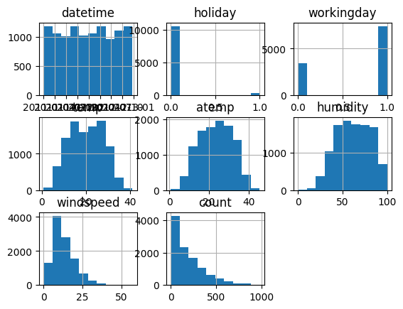

```python
# View histogram of all features again now with the new feature
train.hist()
```

## Step 5: Rerun the model with the same settings as before, just with more features

```python
predictor_new_features = TabularPredictor(label='count', eval_metric='root_mean_squared_error').fit(train, time_limit= 10*60, presets="best_quality")
```

[output not shown]

[output cut: 94 more lines]

[output not shown]

```python
predictor_new_features.fit_summary()
```

```
*** Summary of fit() ***
Estimated performance of each model:
                     model   score_val  pred_time_val    fit_time  pred_time_val_marginal  fit_time_marginal  stack_level  can_infer  fit_order
0      WeightedEnsemble_L3  -50.716886      12.965063  397.039448                0.000000           0.217050            3       True         20
1   NeuralNetFastAI_BAG_L2  -52.392568      12.158018  389.859026                0.334090          20.687970            2       True         17
2   RandomForestMSE_BAG_L2  -53.028670      12.226212  374.557781                0.402284           5.386725            2       True         14
3     ExtraTreesMSE_BAG_L2  -54.024953      12.228688  370.747704                0.404760           1.576648            2       True         16
4          LightGBM_BAG_L2  -54.667035      12.026694  372.968209                0.202766           3.797153            2       True         13
5           XGBoost_BAG_L2  -54.921636      11.937957  375.573048                0.114029           6.401992            2       True         18
6          CatBoost_BAG_L2  -55.456502      11.868282  481.594696                0.044354         112.423640            2       True         15
7        LightGBMXT_BAG_L2  -61.517953      16.257257  379.500584                4.433330          10.329528            2       True         12
8    NeuralNetTorch_BAG_L2  -63.481691      12.119495  388.807302                0.295568          19.636246            2       True         19
9      WeightedEnsemble_L2  -84.146423       0.015626    0.302041                0.000000           0.261009            2       True         11
10   KNeighborsDist_BAG_L1  -84.146423       0.015626    0.041031                0.015626           0.041031            1       True          2
11   KNeighborsUnif_BAG_L1 -101.588176       0.015617    0.035099                0.015617           0.035099            1       True          1
12  RandomForestMSE_BAG_L1 -116.705026       0.365784    1.849526                0.365784           1.849526            1       True          5
13    ExtraTreesMSE_BAG_L1 -124.395497       0.407940    0.879705                0.407940           0.879705            1       True          7
14         LightGBM_BAG_L1 -130.339419       0.935308    4.580270                0.935308           4.580270            1       True          4
15          XGBoost_BAG_L1 -131.127673       0.169674    4.548104                0.169674           4.548104            1       True          9
16       LightGBMXT_BAG_L1 -131.159177       9.178683    9.561656                9.178683           9.561656            1       True          3
17         CatBoost_BAG_L1 -131.926344       0.098167  296.033499                0.098167         296.033499            1       True          6
18  NeuralNetFastAI_BAG_L1 -135.319839       0.377352   23.333002                0.377352          23.333002            1       True          8
19   NeuralNetTorch_BAG_L1 -140.735726       0.259778   28.309164                0.259778          28.309164            1       True         10
Number of models trained: 20
Types of models trained:
{'WeightedEnsembleModel', 'StackerEnsembleModel_NNFastAiTabular', 'StackerEnsembleModel_XT', 'StackerEnsembleModel_LGB', 'StackerEnsembleModel_XGBoost', 'StackerEnsembleModel_CatBoost', 'StackerEnsembleModel_TabularNeuralNetTorch', 'StackerEnsembleModel_KNN', 'StackerEnsembleModel_RF'}
Bagging used: True  (with 8 folds)
Multi-layer stack-ensembling used: True  (with 3 levels)
Feature Metadata (Processed):
(raw dtype, special dtypes):
('category', [])             : 3 | ['season', 'weather', 'weekday']
('float', [])                : 3 | ['temp', 'atemp', 'windspeed']
('int', [])                  : 1 | ['humidity']
('int', ['bool'])            : 2 | ['holiday', 'workingday']
('int', ['datetime_as_int']) : 5 | ['datetime', 'datetime.year', 'datetime.month', 'datetime.day', 'datetime.dayofweek']
Plot summary of models saved to file: AutogluonModels/ag-20220902_205304\SummaryOfModels.html
*** End of fit() summary ***
```

[output not shown]

[output cut: 199 more lines]

[output not shown]

```python
predictions =predictor_new_features.predict(test)

predictions.head()
```

```
0    21.664917
1    38.891357
2    44.282181
3    46.112419
4    48.258797
Name: count, dtype: float32
```

```python
predictions.describe()
```

```
count    6493.000000
mean       99.635452
std        88.495079
min        -2.982982
25%        22.031036
50%        68.172020
75%       166.278473
max       355.339722
Name: count, dtype: float64
```

```python
# Remember to set all negative values to zero
b=np.array(predictions)
print(sum(b<0))
```

```
37
```

```python
predictions=np.where(predictions < 0.0, 0, predictions)
```

```python
b=np.array(predictions)
print(sum(b<0))
```

```
0
```

```python
submission_new_features= pd.read_csv('data/sampleSubmission.csv')
```

```python
# Same submitting predictions
submission_new_features["count"] = predictions
submission_new_features.to_csv("submission_new_features.csv", index=False)
```

```python
!kaggle competitions submit -c bike-sharing-demand -f submission_new_features.csv -m "new features"
```

```
Successfully submitted to Bike Sharing Demand
```

```
  4%|4         | 8.00k/195k [00:00<00:06, 27.8kB/s]
 41%|####1     | 80.0k/195k [00:00<00:00, 181kB/s]
 53%|#####3    | 104k/195k [00:01<00:01, 64.8kB/s]
 99%|#########8| 192k/195k [00:01<00:00, 143kB/s]
```

```python
!kaggle competitions submissions -c bike-sharing-demand | tail -n +1 | head -n 6
```

```
'tail' is not recognized as an internal or external command,
operable program or batch file.
```

#### New Score of `1.82964`

```python
test.to_csv('data/test_newf.csv',index=False)
```

```python
train.to_csv('data/train_newf.csv',index=False)
```

## Step 6: Hyper parameter optimization

- There are many options for hyper parameter optimization.
- Options are to change the AutoGluon higher level parameters or the individual model hyperparameters.
- The hyperparameters of the models themselves that are in AutoGluon. Those need the `hyperparameter` and `hyperparameter_tune_kwargs` arguments.

```python
train=pd.read_csv('data/train_newf.csv')
test=pd.read_csv('data/test_newf.csv')
```

```python
nn_options = {
    'num_epochs': 10,
    'learning_rate': ag.space.Real(1e-4, 1e-2, default=5e-4, log=True),
    'activation': ag.space.Categorical('relu', 'softrelu', 'tanh'),
    'dropout_prob': ag.space.Real(0.0, 0.5, default=0.1),
}

gbm_options = {
    'num_boost_round': 100,
    'num_leaves': ag.space.Int(lower=26, upper=66, default=36),
}
search_strategy = 'auto'
num_trials = 5
hyperparameters={'GBM': gbm_options,'NN_TORCH': nn_options}
hyperparameter_tune_kwargs = {'num_trials': num_trials,'scheduler' : 'local','searcher': search_strategy,}
```

```python
predictor_new_hpo =TabularPredictor(label='count', eval_metric='root_mean_squared_error').fit(train, time_limit= 10*60, presets="best_quality", hyperparameters=hyperparameters, hyperparameter_tune_kwargs=hyperparameter_tune_kwargs)
```

[output not shown]

[output not shown]

[output cut: 264 more lines]

[output not shown]

[output not shown]

[output cut: 71 more lines]

[output not shown]

```python
predictor_new_hpo.fit_summary()
```

```
*** Summary of fit() ***
Estimated performance of each model:
                       model   score_val  pred_time_val    fit_time  pred_time_val_marginal  fit_time_marginal  stack_level  can_infer  fit_order
0        WeightedEnsemble_L3 -130.850674       5.842651  227.239566                0.001000           0.169149            3       True         13
1         LightGBM_BAG_L2\T2 -130.911450       4.293290  156.100158                0.137603           7.978801            2       True          8
2         LightGBM_BAG_L2\T1 -131.346579       4.349871  155.865875                0.194184           7.744517            2       True          7
3         LightGBM_BAG_L2\T3 -131.422480       4.697021  157.296209                0.541333           9.174851            2       True          9
4         LightGBM_BAG_L2\T5 -131.664086       4.401690  156.766960                0.246003           8.645602            2       True         11
5        WeightedEnsemble_L2 -133.379265       1.815723   58.994343                0.001000           0.155984            2       True          6
6         LightGBM_BAG_L1\T3 -133.379651       1.084550   30.420599                1.084550          30.420599            1       True          3
7         LightGBM_BAG_L1\T2 -134.254126       0.730172   28.417760                0.730172          28.417760            1       True          2
8   NeuralNetTorch_BAG_L2\T1 -134.334384       5.162714  209.916765                1.007027          61.795407            2       True         12
9         LightGBM_BAG_L1\T1 -134.709186       0.855677   29.671609                0.855677          29.671609            1       True          1
10        LightGBM_BAG_L1\T5 -135.225529       0.850456   30.205107                0.850456          30.205107            1       True          5
11        LightGBM_BAG_L2\T4 -148.463475       4.318447  156.000533                0.162760           7.879175            2       True         10
12        LightGBM_BAG_L1\T4 -155.765120       0.634832   29.406282                0.634832          29.406282            1       True          4
Number of models trained: 13
Types of models trained:
{'StackerEnsembleModel_LGB', 'WeightedEnsembleModel', 'StackerEnsembleModel_TabularNeuralNetTorch'}
Bagging used: True  (with 8 folds)
Multi-layer stack-ensembling used: True  (with 3 levels)
Feature Metadata (Processed):
(raw dtype, special dtypes):
('float', [])                : 3 | ['temp', 'atemp', 'windspeed']
('int', [])                  : 4 | ['season', 'weather', 'humidity', 'weekday']
('int', ['bool'])            : 2 | ['holiday', 'workingday']
('int', ['datetime_as_int']) : 5 | ['datetime', 'datetime.year', 'datetime.month', 'datetime.day', 'datetime.dayofweek']
Plot summary of models saved to file: AutogluonModels/ag-20220902_235826\SummaryOfModels.html
*** End of fit() summary ***
```

[output not shown]

[output cut: 109 more lines]

[output not shown]

```python
predictions_new_hpo=predictor_new_hpo.predict(test)
predictions_new_hpo.head()
```

```
0    71.008919
1    51.676960
2    51.676960
3    63.548096
4    63.548092
Name: count, dtype: float32
```

```python
predictions_new_hpo.describe()
```

```
count    6493.000000
mean      197.187607
std       121.983383
min        29.506687
25%       111.334335
50%       162.022858
75%       270.015839
max       620.350769
Name: count, dtype: float64
```

# No negetive values

```python
# Same submitting predictions
submission_new_hpo= pd.read_csv('data/sampleSubmission.csv')
submission_new_hpo["count"] = predictions_new_hpo
submission_new_hpo.to_csv("submission_new_hpo.csv", index=False)
```

```python
!kaggle competitions submit -c bike-sharing-demand -f submission_new_hpo.csv -m "new features with hyperparameters"
```

```
Successfully submitted to Bike Sharing Demand
```

[output not shown]

```python
!kaggle competitions submissions -c bike-sharing-demand | tail -n +1 | head -n 6
```

#### New Score of `1.31684`

## Step 7: Write a Report

### Refer to the markdown file for the full report

### Creating plots and table for report

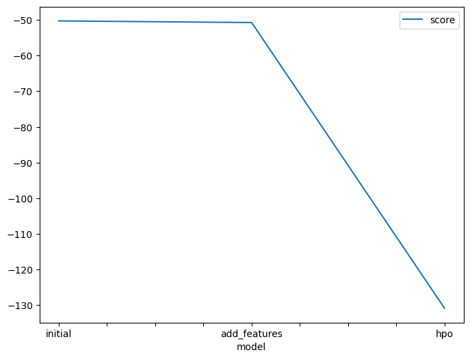

```python
# Taking the top model score from each training run and creating a line plot to show improvement
# You can create these in the notebook and save them to PNG or use some other tool (e.g. google sheets, excel)
fig = pd.DataFrame(
    {
        "model": ["initial", "add_features", "hpo"],
        "score": [-50.257112 , -50.716886, -130.850674]
    }
).plot(x="model", y="score", figsize=(8, 6)).get_figure()
fig.savefig('model_train_score.png')
```

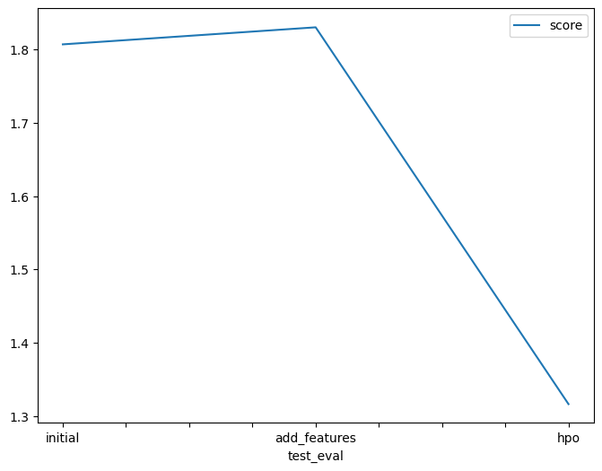

```python
# Take the 3 kaggle scores and creating a line plot to show improvement
fig = pd.DataFrame(
    {
        "test_eval": ["initial", "add_features", "hpo"],
        "score": [1.80644, 1.82964, 1.31684]
    }
).plot(x="test_eval", y="score", figsize=(8, 6)).get_figure()
fig.savefig('model_test_score.png')
```

### Hyperparameter table

```python
# The 3 hyperparameters we tuned with the kaggle score as the result
pd.DataFrame({
    "model": ["initial", "add_features", "hpo"],
    "hpo1": ['best_quility', 'best_quility', 'nn_options'],
    "hpo2": ['time_limit_10m', 'time_limit_10m', 'time_limit_10m'],
    "hpo3": ['none','none' , 'gbm_options'],
    "score": [1.80644, 1.82964, 1.31684]
})
```

|  | model | hpo1 | hpo2 | hpo3 | score |
| --- | --- | --- | --- | --- | --- |
| 0 | initial | best_quility | time_limit_10m | none | 1.80644 |
| 1 | add_features | best_quility | time_limit_10m | none | 1.82964 |
| 2 | hpo | nn_options | time_limit_10m | gbm_options | 1.31684 |